# Statistical Machine Learning application to Education in Argentina

Cande Torres and Kashvi Ajitsaria

5/5/2021

```r
library(tidyverse)
library(readr)
library(ggplot2)
library(dplyr)
library(caret)
library(rpart.plot)
library(randomForest)
```

```r
library(ISLR)
library(tidyverse)
library(tidyr)
library(readr)
library(ggplot2)
library(dplyr)
library(forcats)
library(carData)
library(class)
library(devtools)
library(gam)
library(glmnet)
library(leaps)
library(methods)
library(openxlsx)
library(scales)
library(splines)
library(stats)
library(caret)
library(broom)
```

# Data

Our data is from Argentina’s national ‘Permanent Household Survey’, which is collected by the National Institute of Statistics and Censuses on a 3-month basis for a subset of the larger population. Each one of the cases in our final clean dataset represents the profile of an individual included in Argentina’s national household survey, wherein we have information relating to their demographic status, access to information and communication technology, household situation, and educational attainment. This information is made tangible through 5 key variables - **ICT_access_index**: which encompasses data about household computers, cell phones and internet access and usage; **Educational Attainment**: which describes the difference in educational status between 2019 and 2020 in the form of a binary variable where 1 describes educational progress; **Income Individual**: which represents the amount of money earned through labor each month; **Type of school**: which represents whether education was through a public or private institution; and **Aglomerado**: which represents the region of Argentine the individual is from. We have 6 additional variables documenting individuals’ sex, marriage status, access to individual room at home, access to study room, highest level of education and age.

```r
data2019 <- read_csv("/Users/cande/Desktop/SPRING 2021/Module 4/STATS-253/project/Data/STATS_project_data2019.csv")
```

```
## * `` -> ...1
```

```r
# Remove the variables we don't want
data2019 <- data2019 %>%
    select(-ANO4, -TRIMESTRE,-COMPONENTE,-CODUSU,-NRO_HOGAR,-Birth_Loc_Specific, -Location_5y_Specific,-Read_write_recode,-Schooling_recode,-NIVEL_ED_recoded,-ESTADO,-CAT_INAC,-Income_job,-Income_scholarship, -Income_no_work, -IPCF,-NIVEL_ED,-Schooling,-Read_write)
```

```r
#Recode Vars taken as integer as categorical
data2019$CAT_OCUP <- as.factor(data2019$CAT_OCUP)
data2019$Sex <- as.factor(data2019$Sex)
data2019$REGION <- as.factor(data2019$REGION)
data2019$Relative_Rel <- as.factor(data2019$Relative_Rel)
data2019$Civil_State <- as.factor(data2019$Civil_State)
#data2019$Schooling <- as.factor(data2019$Schooling)
#data2019$NIVEL_ED <- as.factor(data2019$NIVEL_ED)
data2019$Highest_level <- as.factor(data2019$Highest_level)
data2019$Type_of_school <- as.factor(data2019$Type_of_school)
data2019$`finished?` <- as.factor(data2019$`finished?`)
data2019$Birth_Location <- as.factor(data2019$Birth_Location)
data2019$Ownership <- as.factor(data2019$Ownership)
data2019$House_Type <- as.factor(data2019$House_Type)
data2019$Studio <- as.factor(data2019$Studio)
data2019$IH_II_01 <- as.factor(data2019$IH_II_01)
data2019$IH_II_02 <- as.factor(data2019$IH_II_02)
data2019$IP_III_04 <- as.factor(data2019$IP_III_04)
data2019$IP_III_05 <- as.factor(data2019$IP_III_05)
data2019$IP_III_06 <- as.factor(data2019$IP_III_06)
```

```r
# Rename column where names is code
names(data2019)[names(data2019) == "IH_II_01"] <- "Computer_house"
names(data2019)[names(data2019) == "IH_II_02"] <- "Internet_house"
names(data2019)[names(data2019) == "IP_III_04"] <- "Internet_use"
names(data2019)[names(data2019) == "IP_III_05"] <- "Computer_use"
names(data2019)[names(data2019) == "IP_III_06"] <- "Cellphone_use"
```

```r
head(data2019)
```

```
## # A tibble: 6 × 33
##    ...1 Ind_Interview REGION MAS_500 AGLOMERADO Relative_Rel Sex     Age
##   <dbl>         <dbl> <fct>  <chr>        <dbl> <fct>        <fct> <dbl>
## 1     1             1 43     S                2 1            1        44
## 2     2             1 43     S                2 1            1        59
## 3     3             1 43     S                2 2            2        62
## 4     4             1 43     S                2 3            1        26
## 5     5             1 43     S                2 3            1        23
## 6     6             1 43     S                2 1            2        26
## # … with 25 more variables: Civil_State <fct>, Type_of_school <fct>,
## #   Highest_level <fct>, finished? <fct>, last_yr_approved <chr>,
## #   Birth_Location <fct>, Location_5y <dbl>, CAT_OCUP <fct>, JOB_N <dbl>,
## #   Income_individual <dbl>, ITF <dbl>, person_id <dbl>, Internet_use <fct>,
## #   Computer_use <fct>, Cellphone_use <fct>, House_Type <fct>, Room_N <dbl>,
## #   Ownership <fct>, Self_Room <dbl>, Self_Room_Sleep <dbl>, Studio <fct>,
## #   Studio_N <dbl>, Computer_house <fct>, Internet_house <fct>, …
```

**Goal and Research Questions**

Our analysis goal for this project is to predict income of individuals in Argentina, as well as the extent of educational disruption during the COVID-19 pandemic, based on different factors such as region of origin, sex and access to information and communication technologies (ICTs).

In the **regression section**, we explore: Which variables help us predict an Argentinian person’s income, measured in pesos? In the **classification section**, we explore: Which variables help us predict whether an individual’s education was disrupted or not during the COVID-19 pandemic, where educational attainment is measured in 0 = no progress and 1 = made progress?

## Initial investigation 1: ignoring nonlinearity (for now)

Use ordinary least squares (OLS) regression, forward and/or backward selection, and LASSO to build initial models for your quantitative outcome as a function of the predictors of interest. (As part of data cleaning, exclude any variables that you don’t want to consider as predictors.)

- These models should not include any transformations to deal with nonlinearity. You’ll explore this in the next investigation.
- Note: If you have highly collinear/redundant variables, you might see the message “Reordering variables and trying again” and associated `warning()`s about linear dependencies being found. Sometimes stepwise selection is able to handle the collinearity/redundancy by modifying the order of the variables tried. If collinearity/redundancy cannot be handled and causes an error, try reducing `nvmax`.

# Introduction

For the regression analysis, we used the Backward stepwise selection and LASSO regression with splines to evaluate non-linear relationships between variables, which we complemented by fitting GAMs. We evaluated these models by computing the root-mean squared error (RMSE), as well as looking at the model’s variable importance measures and simplicity.

**Note**: It is noteworthy the fact that we started fitting the models with individual’s income as outcome variable in the natural scale. Only when we got to the residuals plot we realized we needed to log transform the variable to account for non-continuous distribution of residuals or heteroskedasticity. We log transformed the variable and re-traced the process but for the sake of interpretability, we are stiking with the natural scale for now.

**OLS**

**Note** : We kept the original OLS models to compare residual plots bellow

```r
mod1 <- lm(Income_individual ~ Literacy_Index+Sex+Birth_Location+CAT_OCUP+Civil_State+Highest_level+Cellphone_use+Internet_use+ Computer_use+ Age, data = data2019)
summary(mod1)
```

```
##
## Call:
## lm(formula = Income_individual ~ Literacy_Index + Sex + Birth_Location +
##     CAT_OCUP + Civil_State + Highest_level + Cellphone_use +
##     Internet_use + Computer_use + Age, data = data2019)
##
## Residuals:
##     Min      1Q  Median      3Q     Max
##  -73464   -8292   -1112    5111 1642734
##
## Coefficients:
##                   Estimate Std. Error t value Pr(>|t|)
## (Intercept)      -3560.759   1348.796  -2.640 0.008294 **
## Literacy_Index    2047.797    227.197   9.013  < 2e-16 ***
## Sex2             -4561.713    200.031 -22.805  < 2e-16 ***
## Birth_Location2   1268.776    336.442   3.771 0.000163 ***
## Birth_Location3   2341.698    288.152   8.127 4.52e-16 ***
## Birth_Location4   -465.529    595.578  -0.782 0.434429
## Birth_Location5  -2075.497    942.160  -2.203 0.027605 *
## Birth_Location9  -5622.637   6125.785  -0.918 0.358695
## CAT_OCUP1        17333.102    702.696  24.667  < 2e-16 ***
## CAT_OCUP2         5822.716    331.584  17.560  < 2e-16 ***
## CAT_OCUP3        13199.429    229.878  57.419  < 2e-16 ***
## CAT_OCUP4        -3394.074   1685.685  -2.013 0.044071 *
## CAT_OCUP9        -2725.913  21367.652  -0.128 0.898488
## Civil_State2      1176.670    306.090   3.844 0.000121 ***
## Civil_State3      2322.998    437.821   5.306 1.13e-07 ***
## Civil_State4      3871.796    524.968   7.375 1.67e-13 ***
## Civil_State5     -3608.130    291.161 -12.392  < 2e-16 ***
## Civil_State9     -2558.198  12777.654  -0.200 0.841318
## Highest_level1    2286.799   3439.338   0.665 0.506121
## Highest_level2   -4622.205   1495.991  -3.090 0.002005 **
## Highest_level3   -3559.696   1764.270  -2.018 0.043632 *
## Highest_level4   -6258.179   1763.005  -3.550 0.000386 ***
## Highest_level5   -4557.700   1963.588  -2.321 0.020285 *
## Highest_level6   -6501.692   2134.393  -3.046 0.002319 **
## Highest_level7   -3082.126   2115.504  -1.457 0.145144
## Highest_level8   22430.338   2446.080   9.170  < 2e-16 ***
## Highest_level9    3140.726   1898.742   1.654 0.098112 .
## Highest_level99 -16965.338   9336.962  -1.817 0.069222 .
## Cellphone_use2     369.912    375.402   0.985 0.324445
## Cellphone_use9    1985.503  12296.952   0.161 0.871729
## Internet_use2    -2208.172    332.085  -6.649 2.97e-11 ***
## Internet_use9    -5744.849   7277.502  -0.789 0.429883
## Computer_use2    -3221.570    226.905 -14.198  < 2e-16 ***
## Computer_use9    -3343.862   4459.193  -0.750 0.453330
## Age                277.369      7.586  36.561  < 2e-16 ***
## ---
## Signif. codes:  0 '***' 0.001 '**' 0.01 '*' 0.05 '.' 0.1 ' ' 1
##
## Residual standard error: 21370 on 49944 degrees of freedom
##   (23 observations deleted due to missingness)
## Multiple R-squared:  0.2363, Adjusted R-squared:  0.2358
## F-statistic: 454.5 on 34 and 49944 DF,  p-value: < 2.2e-16
```

```r
mod1_output <- broom::augment(mod1, newdata = data2019)
head(mod1_output)
```

```
## # A tibble: 6 × 35
##    ...1 Ind_Interview REGION MAS_500 AGLOMERADO Relative_Rel Sex     Age
##   <dbl>         <dbl> <fct>  <chr>        <dbl> <fct>        <fct> <dbl>
## 1     1             1 43     S                2 1            1        44
## 2     2             1 43     S                2 1            1        59
## 3     3             1 43     S                2 2            2        62
## 4     4             1 43     S                2 3            1        26
## 5     5             1 43     S                2 3            1        23
## 6     6             1 43     S                2 1            2        26
## # … with 27 more variables: Civil_State <fct>, Type_of_school <fct>,
## #   Highest_level <fct>, finished? <fct>, last_yr_approved <chr>,
## #   Birth_Location <fct>, Location_5y <dbl>, CAT_OCUP <fct>, JOB_N <dbl>,
## #   Income_individual <dbl>, ITF <dbl>, person_id <dbl>, Internet_use <fct>,
## #   Computer_use <fct>, Cellphone_use <fct>, House_Type <fct>, Room_N <dbl>,
## #   Ownership <fct>, Self_Room <dbl>, Self_Room_Sleep <dbl>, Studio <fct>,
## #   Studio_N <dbl>, Computer_house <fct>, Internet_house <fct>, …
```

```r
set.seed(253)

mod1_cv <- train(
    Income_individual ~ Literacy_Index+Sex+Birth_Location+CAT_OCUP+Civil_State+Highest_level+Cellphone_use+Internet_use+ Computer_use+ Age,
    data= data2019,
    method= "lm",
    trControl= trainControl(method="cv", number = 10),
    na.action = na.omit
)
```

```r
summary(mod1_cv)
```

```
##
## Call:
## lm(formula = .outcome ~ ., data = dat)
##
## Residuals:
##     Min      1Q  Median      3Q     Max
##  -73464   -8292   -1112    5111 1642734
##
## Coefficients:
##                   Estimate Std. Error t value Pr(>|t|)
## (Intercept)      -3560.759   1348.796  -2.640 0.008294 **
## Literacy_Index    2047.797    227.197   9.013  < 2e-16 ***
## Sex2             -4561.713    200.031 -22.805  < 2e-16 ***
## Birth_Location2   1268.776    336.442   3.771 0.000163 ***
## Birth_Location3   2341.698    288.152   8.127 4.52e-16 ***
## Birth_Location4   -465.529    595.578  -0.782 0.434429
## Birth_Location5  -2075.497    942.160  -2.203 0.027605 *
## Birth_Location9  -5622.637   6125.785  -0.918 0.358695
## CAT_OCUP1        17333.102    702.696  24.667  < 2e-16 ***
## CAT_OCUP2         5822.716    331.584  17.560  < 2e-16 ***
## CAT_OCUP3        13199.429    229.878  57.419  < 2e-16 ***
## CAT_OCUP4        -3394.074   1685.685  -2.013 0.044071 *
## CAT_OCUP9        -2725.913  21367.652  -0.128 0.898488
## Civil_State2      1176.670    306.090   3.844 0.000121 ***
## Civil_State3      2322.998    437.821   5.306 1.13e-07 ***
## Civil_State4      3871.796    524.968   7.375 1.67e-13 ***
## Civil_State5     -3608.130    291.161 -12.392  < 2e-16 ***
## Civil_State9     -2558.198  12777.654  -0.200 0.841318
## Highest_level1    2286.799   3439.338   0.665 0.506121
## Highest_level2   -4622.205   1495.991  -3.090 0.002005 **
## Highest_level3   -3559.696   1764.270  -2.018 0.043632 *
## Highest_level4   -6258.179   1763.005  -3.550 0.000386 ***
## Highest_level5   -4557.700   1963.588  -2.321 0.020285 *
## Highest_level6   -6501.692   2134.393  -3.046 0.002319 **
## Highest_level7   -3082.126   2115.504  -1.457 0.145144
## Highest_level8   22430.338   2446.080   9.170  < 2e-16 ***
## Highest_level9    3140.726   1898.742   1.654 0.098112 .
## Highest_level99 -16965.338   9336.962  -1.817 0.069222 .
## Cellphone_use2     369.912    375.402   0.985 0.324445
## Cellphone_use9    1985.503  12296.952   0.161 0.871729
## Internet_use2    -2208.172    332.085  -6.649 2.97e-11 ***
## Internet_use9    -5744.849   7277.502  -0.789 0.429883
## Computer_use2    -3221.570    226.905 -14.198  < 2e-16 ***
## Computer_use9    -3343.862   4459.193  -0.750 0.453330
## Age                277.369      7.586  36.561  < 2e-16 ***
## ---
## Signif. codes:  0 '***' 0.001 '**' 0.01 '*' 0.05 '.' 0.1 ' ' 1
##
## Residual standard error: 21370 on 49944 degrees of freedom
## Multiple R-squared:  0.2363, Adjusted R-squared:  0.2358
## F-statistic: 454.5 on 34 and 49944 DF,  p-value: < 2.2e-16
```

*Subset Selection: Backward stepwise selection*

```r
set.seed(25)

back_step_mod <- train(
    Income_individual~ Literacy_Index+Sex+Birth_Location+CAT_OCUP+Civil_State+Highest_level+Cellphone_use+Internet_use+ Computer_use+Age,
    data = data2019,
    method = "leapBackward",
    tuneGrid = data.frame(nvmax = 1:10),
    trControl = trainControl(method = "cv", number = 10, selectionFunction = "oneSE"),
    metric = "MAE",
    na.action = na.omit
)
```

```
## Reordering variables and trying again:
```

```r
summary(back_step_mod)
```

```
## Subset selection object
## 34 Variables  (and intercept)
##                 Forced in Forced out
## Literacy_Index      FALSE      FALSE
## Sex2                FALSE      FALSE
## Birth_Location2     FALSE      FALSE
## Birth_Location3     FALSE      FALSE
## Birth_Location4     FALSE      FALSE
## Birth_Location5     FALSE      FALSE
## Birth_Location9     FALSE      FALSE
## CAT_OCUP1           FALSE      FALSE
## CAT_OCUP2           FALSE      FALSE
## CAT_OCUP3           FALSE      FALSE
## CAT_OCUP4           FALSE      FALSE
## CAT_OCUP9           FALSE      FALSE
## Civil_State2        FALSE      FALSE
## Civil_State3        FALSE      FALSE
## Civil_State4        FALSE      FALSE
## Civil_State5        FALSE      FALSE
## Civil_State9        FALSE      FALSE
## Highest_level1      FALSE      FALSE
## Highest_level2      FALSE      FALSE
## Highest_level3      FALSE      FALSE
## Highest_level4      FALSE      FALSE
## Highest_level5      FALSE      FALSE
## Highest_level6      FALSE      FALSE
## Highest_level7      FALSE      FALSE
## Highest_level8      FALSE      FALSE
## Highest_level9      FALSE      FALSE
## Highest_level99     FALSE      FALSE
## Cellphone_use2      FALSE      FALSE
## Cellphone_use9      FALSE      FALSE
## Internet_use2       FALSE      FALSE
## Internet_use9       FALSE      FALSE
## Computer_use2       FALSE      FALSE
## Computer_use9       FALSE      FALSE
## Age                 FALSE      FALSE
## 1 subsets of each size up to 7
## Selection Algorithm: backward
##          Literacy_Index Sex2 Birth_Location2 Birth_Location3 Birth_Location4
```

[output cut: 48 more lines]

```
## 1  ( 1 ) " "            " "           " "           " "           " "
## 2  ( 1 ) " "            " "           " "           " "           " "
## 3  ( 1 ) " "            " "           " "           " "           " "
## 4  ( 1 ) " "            " "           " "           " "           " "
## 5  ( 1 ) " "            " "           " "           " "           " "
## 6  ( 1 ) " "            " "           " "           " "           " "
## 7  ( 1 ) " "            " "           " "           " "           " "
##          Age
## 1  ( 1 ) " "
## 2  ( 1 ) "*"
## 3  ( 1 ) "*"
## 4  ( 1 ) "*"
## 5  ( 1 ) "*"
## 6  ( 1 ) "*"
## 7  ( 1 ) "*"
```

```r
coef(back_step_mod$finalModel, id = back_step_mod$bestTune$nvmax)
```

```
##    (Intercept) Literacy_Index           Sex2      CAT_OCUP1      CAT_OCUP2
##    -17390.0283      2466.8234     -4155.8548     19185.0613      6416.4241
##      CAT_OCUP3 Highest_level8            Age
##     13965.8905     28848.0022       351.3907
```

**LASSO**

*Note to self*: You can also look at the two forms of penalized models with this tuneGrid: ridge regression and lasso regression. alpha = 0 is pure ridge regression, and alpha = 1 is pure lasso regression. You can fit a mixture of the two models (i.e. an elastic net) using an alpha between 0 and 1. For example, alpha = 0.05 would be 95% ridge regression and 5% lasso regression. *Note to self*: According to the internet, the sequence is the amount of lambda values we explore, starting from a particular number, finishing in a different one. The jumps/steps (amount of models we fit) is defined by length.out and it usually jumps with multiples of 10.

```r
set.seed(253)
lasso_mod<- train(
    Income_individual ~ Literacy_Index+Sex+Birth_Location+CAT_OCUP+Civil_State+Highest_level+Cellphone_use+Internet_use+ Computer_use+Age,
    data = data2019,
    method = "glmnet",
    trControl = trainControl(method = "cv", number = 10, selectionFunction = "oneSE"),
    tuneGrid = data.frame(alpha = 1, lambda = seq(0,1000, length.out = 100)),
    metric = "MAE",
    na.action = na.omit
)
```

# Examine

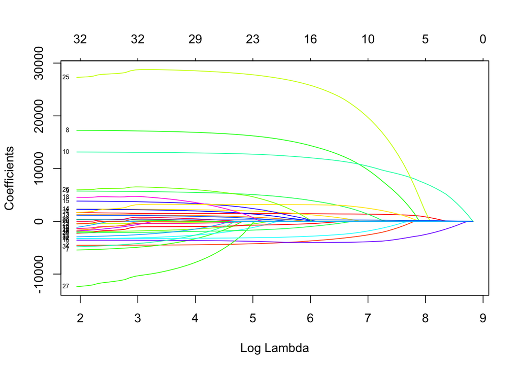

```r
# Plot coefficient paths as a function of lambda
plot(lasso_mod$finalModel, xvar = "lambda", label = TRUE, col = rainbow(20))
```

```r
# Codebook for which variables the numbers correspond to
rownames(lasso_mod$finalModel$beta)
```

```
##  [1] "Literacy_Index"  "Sex2"            "Birth_Location2" "Birth_Location3"
##  [5] "Birth_Location4" "Birth_Location5" "Birth_Location9" "CAT_OCUP1"
##  [9] "CAT_OCUP2"       "CAT_OCUP3"       "CAT_OCUP4"       "CAT_OCUP9"
## [13] "Civil_State2"    "Civil_State3"    "Civil_State4"    "Civil_State5"
## [17] "Civil_State9"    "Highest_level1"  "Highest_level2"  "Highest_level3"
## [21] "Highest_level4"  "Highest_level5"  "Highest_level6"  "Highest_level7"
## [25] "Highest_level8"  "Highest_level9"  "Highest_level99" "Cellphone_use2"
## [29] "Cellphone_use9"  "Internet_use2"   "Internet_use9"   "Computer_use2"
## [33] "Computer_use9"   "Age"
```

- Compare estimated test performance across methods. Which method(s) might you prefer?

**Trainnig Metrics For OLS**

```r
mean(abs(mod1_output$.resid),na.rm=TRUE)
```

```
## [1] 10812.28
```

```r
mean(mod1_output$.resid^2,na.rm=TRUE)
```

```
## [1] 456170460
```

**Test metrics for OLS**

```r
mod1_cv$results
```

```
##   intercept     RMSE Rsquared      MAE   RMSESD RsquaredSD   MAESD
## 1      TRUE 21094.89 0.246132 10823.58 3718.956 0.04361202 131.444
```

**Test Metrics for Stepwise Selection**

```r
# Look at accuracy/error metrics for the different subset sizes
# If you want to sort the table of results, use arrange() from dplyr
back_step_mod$results %>% arrange(MAE)
```

```
##    nvmax     RMSE   Rsquared      MAE   RMSESD RsquaredSD    MAESD
## 1     10 21234.72 0.23416517 11042.38 4116.832 0.06153874 694.4541
## 2      9 21261.29 0.23218020 11089.10 4118.770 0.06253801 712.8859
## 3      8 21310.35 0.22856637 11130.06 4116.526 0.06126135 701.9552
## 4      7 21373.63 0.22381625 11192.71 4098.222 0.05895647 679.9858
## 5      6 21478.07 0.21599135 11305.27 4094.588 0.05893365 704.3734
## 6      5 21656.98 0.20287251 11400.23 4117.168 0.05790163 684.0452
## 7      4 21774.16 0.19398937 11483.82 4094.982 0.05395613 654.8115
## 8      2 22275.11 0.15537183 11509.24 4056.190 0.04510042 683.1004
## 9      3 21879.39 0.18593402 11607.97 4096.273 0.05188570 653.6835
## 10     1 23175.36 0.08371103 13192.98 3954.987 0.02081807 169.9558
```

```r
# What tuning parameter gave the best performance?
# i.e. What subset size gave the best model?
back_step_mod$bestTune
```

```
##   nvmax
## 7     7
```

```r
# Obtain the coefficients for the best model
coef(back_step_mod$finalModel, id = back_step_mod$bestTune$nvmax)
```

```
##    (Intercept) Literacy_Index           Sex2      CAT_OCUP1      CAT_OCUP2
##    -17390.0283      2466.8234     -4155.8548     19185.0613      6416.4241
##      CAT_OCUP3 Highest_level8            Age
##     13965.8905     28848.0022       351.3907
```

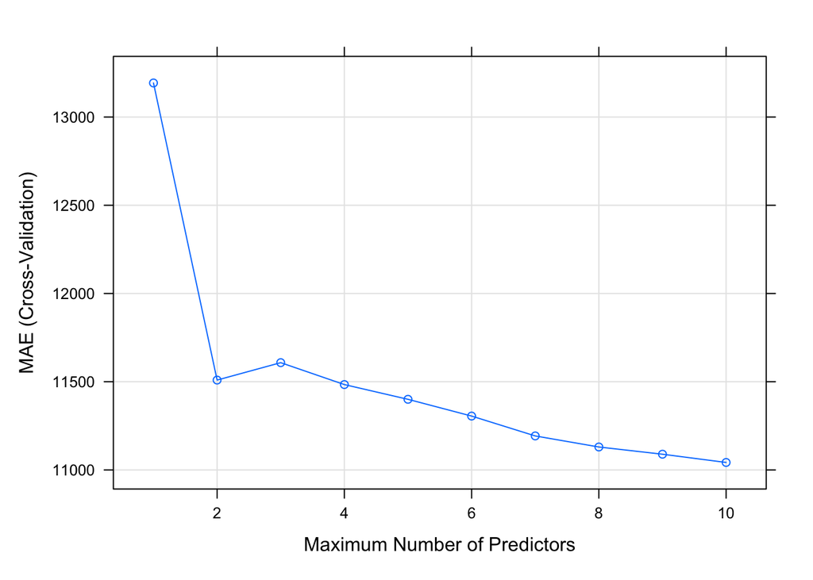

```r
# Plot metrics for each model in the sequence
plot(back_step_mod)
```

**Test Metrics for LASSO**

```r
lasso_mod$results %>% arrange(MAE) %>%
  head(10)
```

```
##    alpha   lambda     RMSE  Rsquared      MAE   RMSESD RsquaredSD    MAESD
## 1      1 353.5354 21136.12 0.2442148 10734.64 3748.399 0.04413983 140.0113
## 2      1 363.6364 21138.36 0.2441160 10734.68 3749.031 0.04414769 140.2292
## 3      1 343.4343 21133.91 0.2443123 10734.75 3747.767 0.04413147 139.8606
## 4      1 373.7374 21140.68 0.2440137 10734.86 3749.654 0.04415511 140.4286
## 5      1 333.3333 21131.69 0.2444124 10734.98 3747.134 0.04412345 139.6634
## 6      1 383.8384 21143.00 0.2439128 10735.12 3750.263 0.04416282 140.6718
## 7      1 393.9394 21145.28 0.2438163 10735.38 3750.803 0.04416733 140.9472
## 8      1 323.2323 21129.54 0.2445090 10735.49 3746.491 0.04411487 139.3761
## 9      1 404.0404 21147.62 0.2437167 10735.78 3751.333 0.04417125 141.2440
## 10     1 313.1313 21127.46 0.2446018 10736.14 3745.838 0.04410584 139.0979
```

```r
# Identify which tuning parameter (lambda) is "best"
lasso_mod$bestTune %>%
  head(10)
```

```
##    alpha   lambda
## 75     1 747.4747
```

```r
#Same thing coded differently, we look at the coefficients for the best lambda model
#coef(lasso_mod_log$finalModel, 747)
coef(lasso_mod$finalModel, lasso_mod$bestTune$lambda)
```

```
## 35 x 1 sparse Matrix of class "dgCMatrix"
##                         s1
## (Intercept)     -3936.9274
## Literacy_Index   1396.6896
## Sex2            -3123.5300
## Birth_Location2     .
## Birth_Location3   500.1259
## Birth_Location4     .
## Birth_Location5     .
## Birth_Location9     .
## CAT_OCUP1       12093.0945
## CAT_OCUP2        2685.7548
## CAT_OCUP3       11279.9739
## CAT_OCUP4           .
## CAT_OCUP9           .
## Civil_State2        .
## Civil_State3        .
## Civil_State4        .
## Civil_State5    -3970.3985
## Civil_State9        .
## Highest_level1      .
## Highest_level2      .
## Highest_level3      .
## Highest_level4      .
## Highest_level5      .
## Highest_level6      .
## Highest_level7   2973.7376
## Highest_level8  22923.2886
## Highest_level9      .
## Highest_level99     .
## Cellphone_use2      .
## Cellphone_use9      .
## Internet_use2    -195.3898
## Internet_use9       .
## Computer_use2   -2392.9450
## Computer_use9       .
## Age               259.7562
```

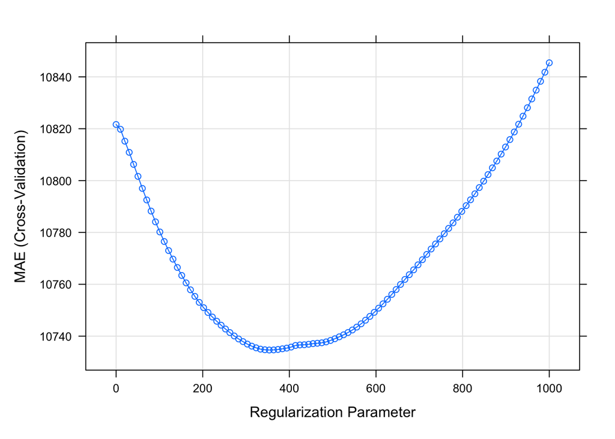

```r
# Plot a summary of the performance of the different models
plot(lasso_mod)
```

**How do the error metrics compare?** *OLS*: The MAE for the 10-variable OLS is 10812.28.This means that on average this OLS model is off in its percentage predictions about a person’s income by about 10812 pesos. The RMSE for OLS is 21094.89, this is the lowest of the three.

*Step-wise*: The MAE for the 10-variable step-wise model is 11042.38. This means that on average this OLS model is off in its percentage predictions about a person’s income by about 11042.38 pesos. The RMSE of the best tune model for backward step selection (7) offers an RMSE of 21373.63

*Lasso*: Based on the information in `lasso_mod$results`, we can see that the lowest estimated test MAE (10734.64) shows up for lambda = 353.5. However, the algorithm decided to set the “best” $\lambda = 747$ model with a MAE of 10777.50 pesos. This means that on average this LASSO model is off in its percentage predictions about a person’s income by about 10778 pesos. The RMSE for the model built with the best lambda is 21231.22

Use residual plots to evaluate whether some quantitative predictors might be better modeled with nonlinear relationships.

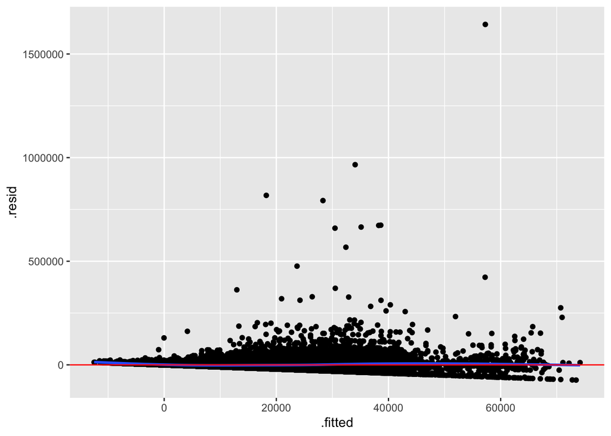

```r
ggplot(mod1_output, aes(x = .fitted, y = .resid)) +
    geom_point() +
    geom_smooth() +
    geom_hline(yintercept = 0, color = "red")
```

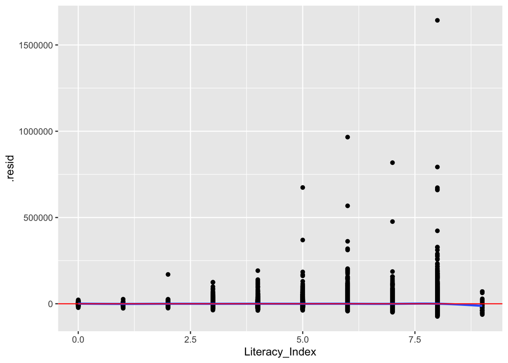

```r
# Residuals vs. Literacy index
ggplot(mod1_output, aes(x = Literacy_Index, y = .resid)) +
    geom_point() +
    geom_smooth() +
    geom_hline(yintercept = 0, color = "red")
```

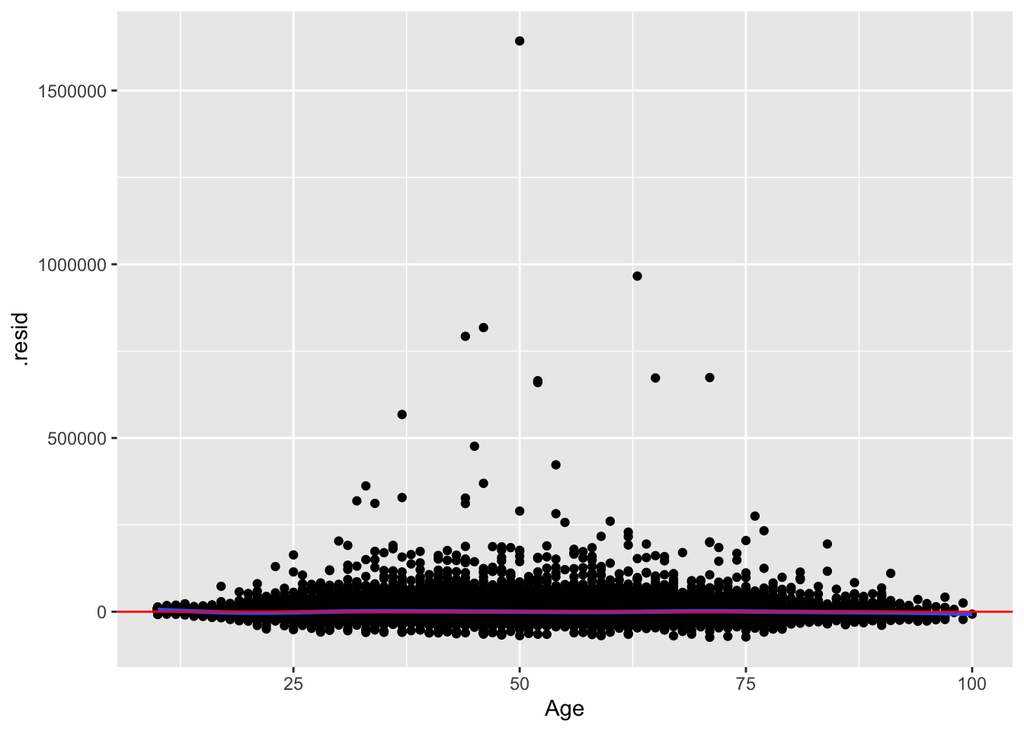

```r
# Residuals vs. Age
ggplot(mod1_output, aes(x = Age, y = .resid)) +
    geom_point() +
    geom_smooth() +
    geom_hline(yintercept = 0, color = "red")
```

Considering the data used only has 2 quantitative predictors, our plots show the residuals vs. the Literacy_Index and Age predictors. The Age distributions look okay, but the Literacy index may indicate the need for a log transform because the distribution of the residuals towards the right seems to hit at heteroskedasticity. We should log transform the outcome Individual Income to see how that affects all our investigation, not only the plot It is worth noticing that even when Literacy is numerical, it does have a delimited set of values, which is depicted in the plot as the vertical columns of residuals. Even when no transformation seems necessary, the warning sign mentions the use of the gam method to plot it which is a good sign that we might want to try non-linear investigations. \

```r
Data2019 <- data2019 %>% mutate(log_income = log(Income_individual+1))
```

```
## Warning in log(Income_individual + 1): NaNs produced
```

```r
data_new <- Data2019                                     # Duplicate data
data_new[is.na(data_new) | data_new == "Inf"] <- NA # Replace NaN & Inf with NA
data_new[is.na(data_new) | data_new == "NaN"] <- NA
```

```r
data_new<-data_new %>%
  filter(!is.na(log_income))
```

```r
mod1_log <- lm(log_income ~ Literacy_Index+Sex+Birth_Location+CAT_OCUP+Civil_State+Highest_level+Cellphone_use+Internet_use+ Computer_use+Age,data = data_new, na.action = na.omit)
summary(mod1_log)
```

```
##
## Call:
## lm(formula = log_income ~ Literacy_Index + Sex + Birth_Location +
##     CAT_OCUP + Civil_State + Highest_level + Cellphone_use +
##     Internet_use + Computer_use + Age, data = data_new, na.action = na.omit)
##
## Residuals:
##      Min       1Q   Median       3Q      Max
## -13.2478  -1.1983  -0.0168   1.6433  10.1126
##
## Coefficients:
##                  Estimate Std. Error t value Pr(>|t|)
## (Intercept)     -0.102346   0.180035  -0.568 0.569713
## Literacy_Index  -0.066566   0.030651  -2.172 0.029881 *
## Sex2            -0.123641   0.026935  -4.590 4.44e-06 ***
## Birth_Location2  0.505625   0.045410  11.135  < 2e-16 ***
## Birth_Location3  0.237649   0.039055   6.085 1.17e-09 ***
## Birth_Location4 -0.176912   0.081143  -2.180 0.029243 *
## Birth_Location5 -0.125105   0.131129  -0.954 0.340060
## Birth_Location9  0.636839   1.232836   0.517 0.605463
## CAT_OCUP1        4.657846   0.103331  45.077  < 2e-16 ***
## CAT_OCUP2        4.270733   0.045943  92.958  < 2e-16 ***
## CAT_OCUP3        5.091827   0.030913 164.717  < 2e-16 ***
## CAT_OCUP4       -0.582917   0.218782  -2.664 0.007716 **
## CAT_OCUP9       -4.022862   2.755771  -1.460 0.144353
## Civil_State2    -0.628923   0.041561 -15.133  < 2e-16 ***
## Civil_State3    -0.241102   0.059882  -4.026 5.68e-05 ***
## Civil_State4     0.320384   0.071176   4.501 6.77e-06 ***
## Civil_State5    -0.798903   0.039320 -20.318  < 2e-16 ***
## Civil_State9     2.095173   4.088108   0.513 0.608301
## Highest_level1   0.124616   0.459121   0.271 0.786067
## Highest_level2   0.316609   0.200285   1.581 0.113932
## Highest_level3   0.943204   0.235046   4.013 6.01e-05 ***
## Highest_level4   0.578385   0.236608   2.444 0.014510 *
## Highest_level5   1.217729   0.262021   4.647 3.37e-06 ***
## Highest_level6   1.269573   0.287083   4.422 9.79e-06 ***
## Highest_level7   1.507984   0.284451   5.301 1.15e-07 ***
## Highest_level8   1.949667   0.335503   5.811 6.24e-09 ***
## Highest_level9   2.941281   0.251068  11.715  < 2e-16 ***
## Highest_level99  0.139335   2.766755   0.050 0.959835
## Cellphone_use2  -0.184407   0.049750  -3.707 0.000210 ***
## Cellphone_use9   2.465357   1.721898   1.432 0.152217
## Internet_use2    0.169168   0.044558   3.797 0.000147 ***
## Internet_use9   -2.261993   1.144391  -1.977 0.048094 *
## Computer_use2    0.123892   0.030536   4.057 4.97e-05 ***
## Computer_use9   -0.206686   0.627158  -0.330 0.741734
## Age              0.112973   0.001027 109.967  < 2e-16 ***
## ---
## Signif. codes:  0 '***' 0.001 '**' 0.01 '*' 0.05 '.' 0.1 ' ' 1
##
## Residual standard error: 2.755 on 45852 degrees of freedom
##   (14 observations deleted due to missingness)
## Multiple R-squared:  0.6396, Adjusted R-squared:  0.6393
## F-statistic:  2393 on 34 and 45852 DF,  p-value: < 2.2e-16
```

```r
mod1_log_output <- broom::augment(mod1_log, newdata = data_new)
head(mod1_log_output)
```

```
## # A tibble: 6 × 36
##    ...1 Ind_Interview REGION MAS_500 AGLOMERADO Relative_Rel Sex     Age
##   <dbl>         <dbl> <fct>  <chr>        <dbl> <fct>        <fct> <dbl>
## 1     1             1 43     S                2 1            1        44
## 2     2             1 43     S                2 1            1        59
## 3     3             1 43     S                2 2            2        62
## 4     6             1 43     S                2 1            2        26
## 5     7             1 43     S                2 1            1        56
## 6     8             1 43     S                2 1            2        35
## # … with 28 more variables: Civil_State <fct>, Type_of_school <fct>,
## #   Highest_level <fct>, finished? <fct>, last_yr_approved <chr>,
## #   Birth_Location <fct>, Location_5y <dbl>, CAT_OCUP <fct>, JOB_N <dbl>,
## #   Income_individual <dbl>, ITF <dbl>, person_id <dbl>, Internet_use <fct>,
## #   Computer_use <fct>, Cellphone_use <fct>, House_Type <fct>, Room_N <dbl>,
## #   Ownership <fct>, Self_Room <dbl>, Self_Room_Sleep <dbl>, Studio <fct>,
## #   Studio_N <dbl>, Computer_house <fct>, Internet_house <fct>, …
```

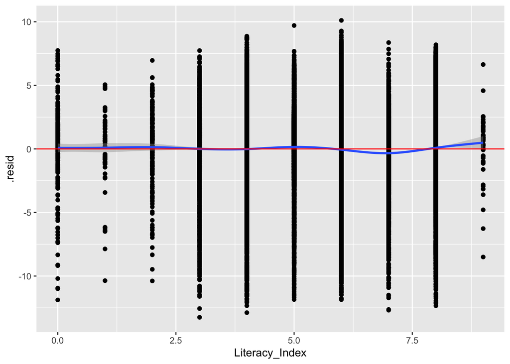

```r
# Residuals vs. Literacy index
ggplot(mod1_log_output, aes(x = Literacy_Index, y = .resid)) +
    geom_point() +
    geom_smooth() +
    geom_hline(yintercept = 0, color = "red")
```

The log transformation helped to fix the non-constant distribution of residuals but there is a trade-off on interpretability. We are staying with natural scales in investigation #1.

Compare insights from variable importance analyses from the different methods (stepwise and LASSO, but not OLS). Are there variables for which the methods reach consensus? What insights are expected? Surprising?

- Note that if some (but not all) of the indicator terms for a categorical predictor are selected in the final models, the whole predictor should be treated as selected.

**LASSO**

```r
# Create a boolean matrix (predictors x lambdas) of variable exclusion
bool_predictor_exclude <- lasso_mod$finalModel$beta==0

# Loop over each variable
var_imp <- sapply(seq_len(nrow(bool_predictor_exclude)), function(row) {
    # Extract coefficient path (sorted from highest to lowest lambda)
    this_coeff_path <- bool_predictor_exclude[row,]
    # Compute and return the # of lambdas until this variable is out forever
    ncol(bool_predictor_exclude)-which.min(this_coeff_path)+1
})

# Create a dataset of this information and sort
var_imp_data <- tibble(
    var_name = rownames(bool_predictor_exclude),
    var_imp = var_imp
)
var_imp_data %>% arrange(desc(var_imp))
```

```
## # A tibble: 34 × 2
##    var_name       var_imp
##    <chr>            <dbl>
##  1 Cellphone_use9      75
##  2 CAT_OCUP3           74
##  3 Age                 74
##  4 Civil_State5        73
##  5 Literacy_Index      70
##  6 Highest_level8      66
##  7 CAT_OCUP1           65
##  8 Sex2                64
##  9 Highest_level7      64
## 10 Computer_use2       62
## # … with 24 more rows
```

## Investigation 2: Accounting for nonlinearity

Update your stepwise selection model(s) and LASSO model to use natural splines for the quantitative predictors.

- You’ll need to update the model formula from `y ~ .` to something like `y ~ cat_var1 + ns(quant_var1, df) + ...`.
- It’s recommended to use few knots (e.g., 2 knots = 3 degrees of freedom).
- Note that `ns(x,3)` replaces `x` with 3 transformations of `x`. Keep this in mind when setting `nvmax` in stepwise selection.

**Stepwise**

```r
set.seed(253)

spline_back_step_mod2 <- train(
    Income_individual~ ns(Literacy_Index,3)+Sex+Birth_Location+CAT_OCUP+Civil_State+Highest_level+Cellphone_use+Internet_use+ Computer_use+ns(Age,3),
    data = data2019,
    method = "leapBackward",
    tuneGrid = data.frame(nvmax = 1:14), #nvmax=number or vars.
    trControl = trainControl(method = "cv", number = 10),
    metric = "MAE",
    na.action = na.omit
)
```

```
## Reordering variables and trying again:
```

```r
summary(spline_back_step_mod2)
```

```
## Subset selection object
## 38 Variables  (and intercept)
##                        Forced in Forced out
## ns(Literacy_Index, 3)1     FALSE      FALSE
## ns(Literacy_Index, 3)2     FALSE      FALSE
## ns(Literacy_Index, 3)3     FALSE      FALSE
## Sex2                       FALSE      FALSE
## Birth_Location2            FALSE      FALSE
## Birth_Location3            FALSE      FALSE
## Birth_Location4            FALSE      FALSE
## Birth_Location5            FALSE      FALSE
## Birth_Location9            FALSE      FALSE
## CAT_OCUP1                  FALSE      FALSE
## CAT_OCUP2                  FALSE      FALSE
## CAT_OCUP3                  FALSE      FALSE
```

[output cut: 163 more lines]

```r
# Look at accuracy/error metrics for the different subset sizes
# If you want to sort the table of results, use arrange() from dplyr
spline_back_step_mod2$results %>% arrange(MAE)
```

```
##    nvmax     RMSE   Rsquared      MAE   RMSESD RsquaredSD    MAESD
## 1     14 21165.22 0.24107381 10809.47 3724.964 0.04384898 131.0383
## 2     13 21196.66 0.23884205 10821.67 3733.309 0.04507788 155.8003
## 3     12 21205.57 0.23817622 10824.09 3732.406 0.04490156 153.6167
## 4     11 21222.37 0.23692563 10834.52 3724.088 0.04425554 151.7327
## 5     10 21300.01 0.23118036 10894.72 3713.738 0.04292123 148.9044
## 6      9 21354.86 0.22710708 10903.06 3710.179 0.04174570 137.6669
## 7      8 21438.07 0.22100174 11075.57 3718.096 0.04197517 178.0557
## 8      7 21577.65 0.21086429 11190.32 3779.432 0.04513555 200.0228
## 9      6 21670.44 0.20389066 11294.99 3762.111 0.04313215 171.6772
## 10     4 21910.07 0.18577803 11434.75 3783.104 0.04575279 495.5613
## 11     5 21822.13 0.19241715 11450.29 3779.249 0.04741749 479.5312
## 12     3 22031.99 0.17647248 11639.67 3772.488 0.04423440 450.7492
## 13     2 22461.53 0.14344219 11996.36 3770.294 0.04006222 379.2329
## 14     1 23219.11 0.08284268 13193.21 3657.685 0.02120588 180.4436
```

```r
spline_back_step_mod2$bestTune
```

```
##    nvmax
## 14    14
```

```r
# Obtain the coefficients for the best model
coef(spline_back_step_mod2$finalModel, id = spline_back_step_mod2$bestTune$nvmax)
```

```
##            (Intercept) ns(Literacy_Index, 3)3                   Sex2
##              10286.720              14013.732              -4308.312
##        Birth_Location3              CAT_OCUP1              CAT_OCUP2
##               2030.464              17596.431               6182.729
##              CAT_OCUP3           Civil_State5         Highest_level6
##              13801.351              -4526.323              -3234.324
##         Highest_level8          Internet_use2          Computer_use2
##              24420.379              -2376.977              -3280.910
##            ns(Age, 3)1            ns(Age, 3)2            ns(Age, 3)3
##              13810.487              19185.984              21795.493
```

**LASSO**

```r
set.seed(253)
spline_lasso_mod2 <- train(
    Income_individual ~ ns(Literacy_Index,3)+Sex+Birth_Location+CAT_OCUP+Civil_State+Highest_level+Cellphone_use+Internet_use+ Computer_use+ns(Age,3),
    data = data2019,
    method = "glmnet",
    trControl = trainControl(method = "cv", number = 10, selectionFunction = "oneSE"),
    tuneGrid = data.frame(alpha = 1, lambda = seq(0,1000, length.out = 100)),#Ask Leslie about length.out
    metric = "MAE",
    na.action = na.omit
)
```

```r
# Identify which tuning parameter (lambda) is "best"
spline_lasso_mod2$bestTune
```

```
##    alpha   lambda
## 54     1 535.3535
```

```r
coef(spline_lasso_mod2$finalModel, lasso_mod$bestTune$lambda)
```

```
## 39 x 1 sparse Matrix of class "dgCMatrix"
##                                s1
## (Intercept)            11775.7161
## ns(Literacy_Index, 3)1     .
## ns(Literacy_Index, 3)2     .
## ns(Literacy_Index, 3)3  9487.5276
## Sex2                   -3319.9355
## Birth_Location2            .
## Birth_Location3          674.0065
## Birth_Location4            .
## Birth_Location5            .
## Birth_Location9            .
## CAT_OCUP1              11278.0200
## CAT_OCUP2               2017.8451
## CAT_OCUP3              10699.1916
## CAT_OCUP4                  .
## CAT_OCUP9                  .
## Civil_State2               .
## Civil_State3               .
## Civil_State4            1951.8274
## Civil_State5           -5057.9354
## Civil_State9               .
## Highest_level1             .
## Highest_level2          -136.9092
## Highest_level3             .
## Highest_level4             .
## Highest_level5             .
## Highest_level6             .
## Highest_level7          2166.9123
## Highest_level8         21113.3501
## Highest_level9             .
## Highest_level99            .
## Cellphone_use2             .
## Cellphone_use9             .
## Internet_use2              .
## Internet_use9              .
## Computer_use2          -1847.6912
## Computer_use9              .
## ns(Age, 3)1            16152.1577
## ns(Age, 3)2             5921.7745
## ns(Age, 3)3             2078.5224
```

```r
spline_lasso_mod2$results
```

```
##     alpha     lambda     RMSE  Rsquared      MAE   RMSESD RsquaredSD    MAESD
## 1       1    0.00000 21083.54 0.2469551 10757.62 3719.019 0.04373398 132.0350
## 2       1   10.10101 21083.49 0.2469631 10756.24 3719.305 0.04373335 131.5917
## 3       1   20.20202 21082.82 0.2470037 10750.56 3720.241 0.04372301 131.1321
## 4       1   30.30303 21082.72 0.2470066 10745.70 3721.166 0.04371228 130.8455
## 5       1   40.40404 21083.17 0.2469734 10741.25 3722.015 0.04369942 130.7271
## 6       1   50.50505 21083.98 0.2469177 10737.13 3722.785 0.04368107 130.6175
## 7       1   60.60606 21085.22 0.2468345 10733.63 3723.453 0.04365608 130.4317
## 8       1   70.70707 21086.81 0.2467280 10730.68 3724.096 0.04362870 130.2122
## 9       1   80.80808 21088.59 0.2466114 10727.97 3724.763 0.04360438 130.1681
## 10      1   90.90909 21090.14 0.2465149 10724.83 3725.494 0.04359549 130.3453
## 11      1  101.01010 21091.39 0.2464433 10721.16 3726.174 0.04359037 130.3587
## 12      1  111.11111 21092.62 0.2463756 10717.47 3726.874 0.04358752 130.3665
## 13      1  121.21212 21093.92 0.2463063 10713.85 3727.533 0.04358009 130.3766
## 14      1  131.31313 21095.26 0.2462372 10710.26 3728.219 0.04357631 130.4406
```

[output cut: 86 more lines]

```r
# Create a boolean matrix (predictors x lambdas) of variable exclusion
bool_predictor_exclude <- spline_lasso_mod2$finalModel$beta==0

# Loop over each variable
var_imp <- sapply(seq_len(nrow(bool_predictor_exclude)), function(row) {
    # Extract coefficient path (sorted from highest to lowest lambda)
    this_coeff_path <- bool_predictor_exclude[row,]
    # Compute and return the # of lambdas until this variable is out forever
    ncol(bool_predictor_exclude)-which.min(this_coeff_path)+1
})

# Create a dataset of this information and sort
var_imp_data <- tibble(
    var_name = rownames(bool_predictor_exclude),
    var_imp = var_imp
)
var_imp_data %>% arrange(desc(var_imp))
```

```
## # A tibble: 38 × 2
##    var_name               var_imp
##    <chr>                    <dbl>
##  1 Cellphone_use9              74
##  2 CAT_OCUP3                   73
##  3 Civil_State5                73
##  4 ns(Age, 3)1                 71
##  5 ns(Literacy_Index, 3)3      70
##  6 Highest_level8              65
##  7 ns(Age, 3)2                 64
##  8 Sex2                        63
##  9 CAT_OCUP1                   63
## 10 Highest_level7              60
## # … with 28 more rows
```

Compare insights from variable importance analyses here and the corresponding results from Investigation 1. Now after having accounted for nonlinearity, have the most relevant predictors changed?

- Note that if some (but not all) of the spline terms are selected in the final models, the whole predictor should be treated as selected.

Using splines transformations for quantitative variables showed us that they remain among the most important predictors when we account for non-linearity in both methods. When one transformation is selected, it accounts for the importance of the whole variable. We can further the exploration using the GAMs \

Fit a GAM using LOESS terms using the set of variables deemed to be most relevant based on your investigations so far.

```r
set.seed(253)
gam_mod <- train(
    Income_individual ~ Literacy_Index+Sex+Birth_Location+CAT_OCUP+Civil_State+Highest_level+Cellphone_use
    +Internet_use+Computer_use+Age,
    data = data2019,
    method = "gamLoess",
    tuneGrid = data.frame(degree = 1, span = seq(0.1, 0.9, by = 0.1)),
    trControl = trainControl(method = "cv", number = 8, selectionFunction = "best"),
    metric = "MAE",
    na.action = na.omit
)
```

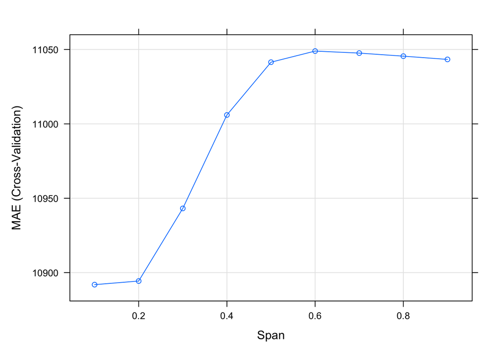

```r
plot(gam_mod)
```

```r
gam_mod$bestTune
```

```
##   span degree
## 1  0.1      1
```

```r
gam_mod$results %>%
    filter(span==gam_mod$bestTune$span)
```

```
##   degree span     RMSE Rsquared      MAE   RMSESD RsquaredSD    MAESD
## 1      1  0.1 21320.16 0.234746 10891.92 2969.295 0.04393753 156.0739
```

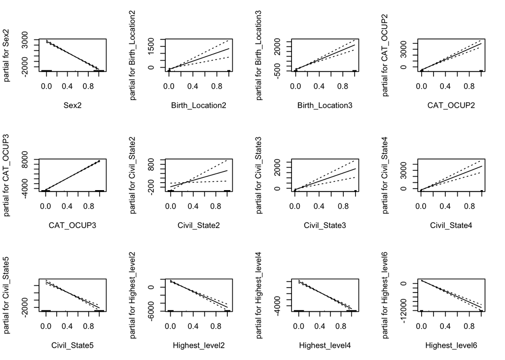

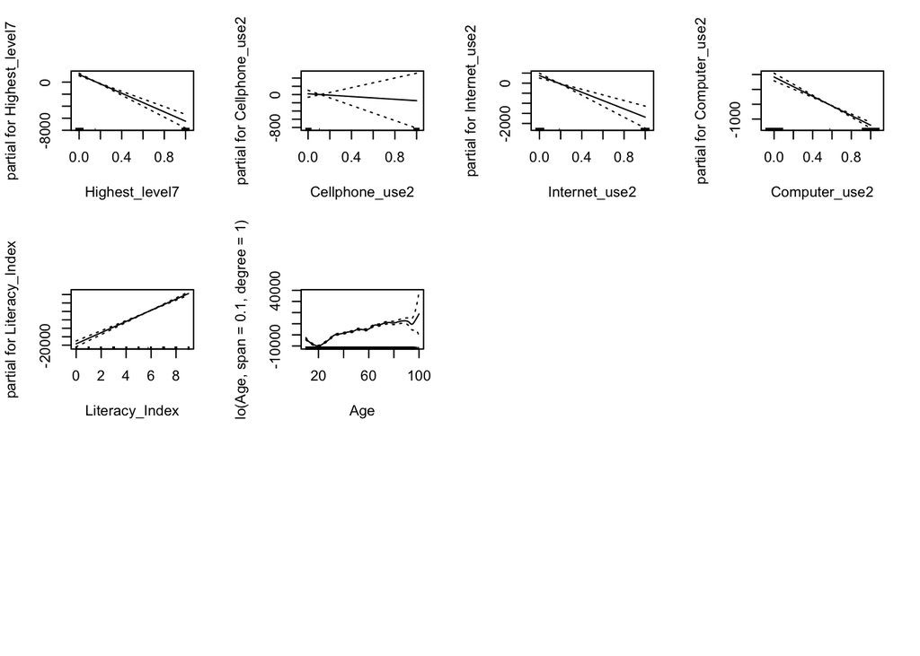

```r
par(mfrow = c(3,4)) # Sets up a grid of plots
plot(gam_mod$finalModel, se = TRUE) # Dashed lines are +/- 2 SEs
```

**How does test performance of the GAM compare to other models you explored?**

The MAE of the GAM is 10891.92. This means that on average this model is off in its percentage predictions about a person’s income by about 10892 pesos.

The Root Mean Square Error (RMSE) is the standard deviation of the residuals (prediction errors). The RMSE for the Lasso with spline models coming from the best lambda is 21211.01 The RMSE for the Backwards selection model considered the best, is 21165.22 The RMSE for the best model coming from GAMs method shows as 21320.16 This means that the method giving the smallest RMSE is the backwards selection model. GAMs yield the largest RMSE of all.

**Do we gain any insights from the GAM output plots for each predictor?**

Since most of the variables are categorical (indicator) variables, we observe linear plots. We can see that among individuals that are same in all other characteristics, those of Sex2 (female) and Civil_State5 (single) have lower average income than others. On the other hand, among individuals that are same in all other characteristics, those of CAT_OCUP 2&3(self employed and worker/employee) and Birth_Location 2&3 (in a county other than the one currently living or in a provice other than the one currently living in) have higher average income than others. \

## Summarize investigations

Decide on an overall best model based on your investigations so far. To do this, make clear your analysis goals. Predictive accuracy? Interpretability? A combination of both?

\

## Societal impact

Are there any harms that may come from your analyses and/or how the data were collected? What cautions do you want to keep in mind when communicating your work?

It is important that we communicate our analyses in a nuanced and non-exaggerated way, based on the relatively significant level of error we have faced so far. If not, this could misguide development programs working in education and digital access. This particular set of analyses, which focuses on income as an outcome of interest, has to effectively address intersectionality and the connection between different social dynamics, in order to ensure holistic development efforts, which do not discriminate against a certain group of people based on pre-existing conditions. If educational and digital access related programmes are not carried out effectively - based on solid evidence - then they could impact the learning, growth and consequently life of many people, causing more harm than good. Thus, it is important to exercise the utmost caution to ensure accuracy and mindfulness of analyses.

\\

# Classification Analysis

_Classification Question__: How does access to ICT impacted educational attainment in Argentina in 2020? _Output Variable__: Educational Attainment

Our goal will be to use people’s characteristics to predict whether or not they achieved progress on their education during 2020.

For the classification analysis, we used logistic regression with LASSO and random forests/bagging. We evaluated these models by computing their overall accuracy, as well as looking at variable importance measures.

**Logistic Regression**

```r
newdataEduAtt <- read.csv("~/Desktop/SPRING 2021/Module 4/STATS-253/project/Data/STATS_project_newdataEduAtt.csv")
```

```r
names(newdataEduAtt)
```

```
##  [1] "X"                 "CODUSU"            "Relative_Rel"
##  [4] "person_id.x"       "last_yr_2019"      "Highest_level.x"
##  [7] "Age19"             "ICT_access_Index"  "Sex"
## [10] "AGLOMERADO"        "Studio"            "Income_individual"
## [13] "Self_Room"         "Civil_State"       "Type_of_school"
## [16] "person_id.y"       "last_yr_2020"      "Highest_level.y"
## [19] "Age20"             "EduAtt"
```

# Recode vars as factors

```r
newdataEduAtt$EduAtt<-as.factor(newdataEduAtt$EduAtt)
newdataEduAtt$Relative_Rel<-as.factor(newdataEduAtt$Relative_Rel)
newdataEduAtt$AGLOMERADO<-as.factor(newdataEduAtt$AGLOMERADO)
newdataEduAtt$Studio<-as.factor(newdataEduAtt$Studio)
newdataEduAtt$Sex<-as.factor(newdataEduAtt$Sex)
newdataEduAtt$Civil_State<-as.factor(newdataEduAtt$Civil_State)
newdataEduAtt$Type_of_school<-as.factor(newdataEduAtt$Type_of_school)
newdataEduAtt$Highest_level.x<-as.factor(newdataEduAtt$Highest_level.x)
newdataEduAtt$Highest_level.y<-as.factor(newdataEduAtt$Highest_level.y)
```

## LASSO LOG

Our goal will be to use people’s characteristics to predict whether or not they achieved progress on their education during 2020.

```r
twoClassSummaryCustom <- function (data, lev = NULL, model = NULL) {
    if (length(lev) > 2) {
        stop(paste("Your outcome has", length(lev), "levels. The twoClassSummary() function isn't appropriate."))
    }
    caret:::requireNamespaceQuietStop("pROC")
    if (!all(levels(data[, "pred"]) == lev)) {
        stop("levels of observed and predicted data do not match")
    }
    rocObject <- try(pROC::roc(data$obs, data[, lev[1]], direction = ">",
        quiet = TRUE), silent = TRUE)
    rocAUC <- if (inherits(rocObject, "try-error"))
        NA
    else rocObject$auc
    out <- c(rocAUC, sensitivity(data[, "pred"], data[, "obs"],
        lev[1]), specificity(data[, "pred"], data[, "obs"], lev[2]))
    out2 <- postResample(data[, "pred"], data[, "obs"])
    out <- c(out, out2[1])
    names(out) <- c("AUC", "Sens", "Spec", "Accuracy")
    out
}
```

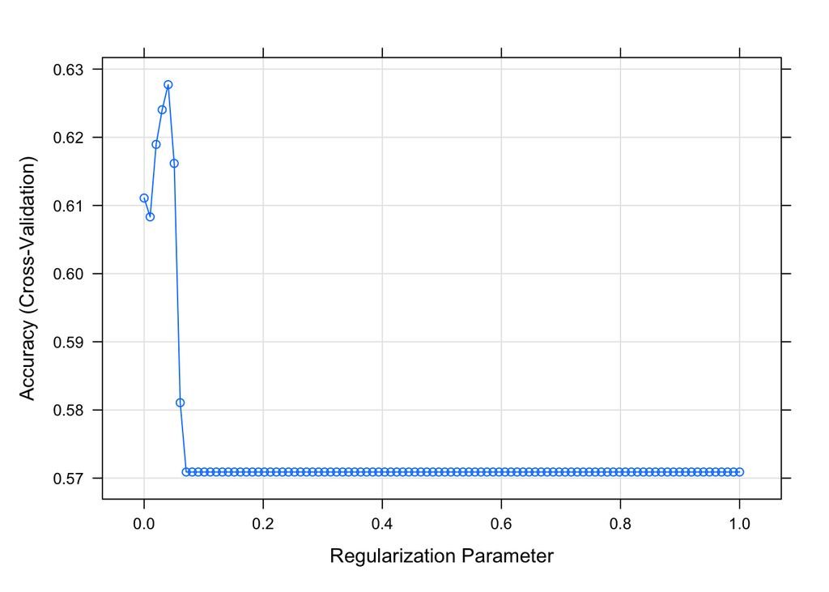

```r
set.seed(148)
lasso_logistic_mod <- train(
    EduAtt~ ICT_access_Index +AGLOMERADO+Sex+Type_of_school+Income_individual+Studio+Age20,
    data = newdataEduAtt,
    method = "glmnet",
    family = "binomial",
    tuneGrid = data.frame(alpha = 1, lambda = seq(0, 1, length.out = 100)),
    trControl = trainControl(method = "cv", number = 10, selectionFunction = "oneSE"),
    metric = "Accuracy",
    na.action = na.omit
)
plot(lasso_logistic_mod)
```

## Variable importance

```r
# Create a boolean matrix (predictors x lambdas) of variable exclusion
bool_predictor_exclude <- lasso_logistic_mod$finalModel$beta==0

# Loop over each variable
var_imp <- sapply(seq_len(nrow(bool_predictor_exclude)), function(row) {
    # Extract coefficient path (sorted from highest to lowest lambda)
    this_coeff_path <- bool_predictor_exclude[row,]
    # Compute and return the # of lambdas until this variable is out forever
    ncol(bool_predictor_exclude)-which.min(this_coeff_path)+1
})

# Create a dataset of this information and sort
var_imp_data <- tibble(
    var_name = rownames(bool_predictor_exclude),
    var_imp = var_imp
)
var_imp_data %>% arrange(desc(var_imp))
```

```
## # A tibble: 37 × 2
##    var_name          var_imp
##    <chr>               <dbl>
##  1 AGLOMERADO30           58
##  2 Type_of_school1        57
##  3 Age20                  56
##  4 AGLOMERADO15           44
##  5 Type_of_school2        43
##  6 AGLOMERADO7            42
##  7 AGLOMERADO8            41
##  8 AGLOMERADO12           41
##  9 Income_individual      40
## 10 AGLOMERADO22           39
## # … with 27 more rows
```

## Evaluate Models

```r
# CV results for "best lambda"
lasso_logistic_mod$results %>%
    filter(lambda==lasso_logistic_mod$bestTune$lambda)
```

```
##   alpha     lambda  Accuracy     Kappa AccuracySD    KappaSD
## 1     1 0.05050505 0.6161696 0.1747644 0.01780104 0.04737276
```

```r
# Count up number of spam and not_spam emails in the training data
newdataEduAtt %>%
    count(EduAtt) # Name of the outcome variable goes inside count()
```

```
##   EduAtt    n
## 1      0 1239
## 2      1  932
```

```r
# Compute the No Information Rate
1239/(1239+932) #This is the relative frequency of the majority class in the outcome variable over all cases.
```

```
## [1] 0.5707047
```

For a lambda at 0.05 considered best by the algorithm, we obtain an accuracy of 62% with this method. Considering that the NIR is 57% this method is not as accurate predicting educational attainment on this data set because just guessing the majority class we would be correct 57% of the times.

```r
lasso_logistic_mod$resample
```

```
##     Accuracy      Kappa Resample
## 1  0.5833333 0.09572984   Fold01
## 2  0.5990783 0.13861386   Fold09
## 3  0.6267281 0.21576763   Fold04
## 4  0.6111111 0.14736842   Fold08
## 5  0.6175115 0.18741259   Fold06
## 6  0.6267281 0.17467249   Fold07
## 7  0.6435185 0.24632953   Fold05
## 8  0.6157407 0.19849785   Fold02
## 9  0.6342593 0.21825179   Fold03
## 10 0.6036866 0.12500000   Fold10
```

# Random Forest for Classification

## Building the random forest

```r
set.seed(253)
rf_mod <- train(
    EduAtt ~ ICT_access_Index+AGLOMERADO+Sex+Type_of_school+Income_individual+Studio+Age20,
    data = newdataEduAtt,
    method = "rf",
    tuneGrid = data.frame(mtry = c(2, 3, 4)),
    trControl = trainControl(method = "oob", selectionFunction = "best"),
    metric = "Accuracy",
    ntree = 1000, # To force fitting 1000 trees (can help with stability of results)
    na.action = na.omit
)
```

## Preliminary interpretation

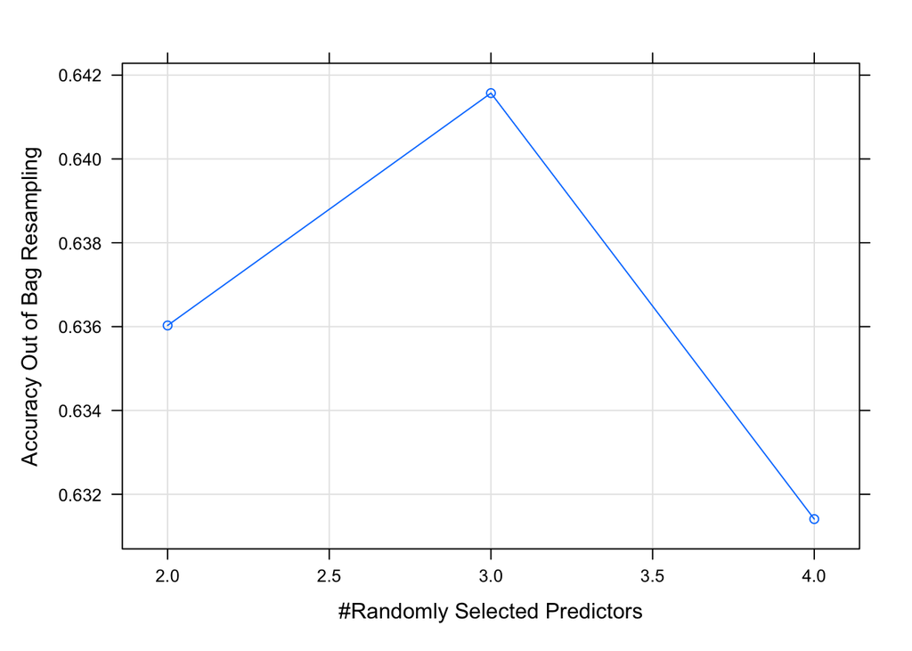

```r
plot(rf_mod)
```

```r
rf_mod$results
```

```
##    Accuracy     Kappa mtry
## 1 0.6360277 0.2425365    2
## 2 0.6415704 0.2524411    3
## 3 0.6314088 0.2287187    4
```

## Evaluating the forest

```r
rf_mod$finalModel
```

```
##
## Call:
##  randomForest(x = x, y = y, ntree = 1000, mtry = min(param$mtry,      ncol(x)))
##                Type of random forest: classification
##                      Number of trees: 1000
## No. of variables tried at each split: 3
##
##         OOB estimate of  error rate: 35.8%
## Confusion matrix:
##     0   1 class.error
## 0 935 301   0.2435275
## 1 474 455   0.5102260
```

## Variable Importance Measures

```r
var_imp_rf <- randomForest::importance(rf_mod$finalModel)

# Sort by importance with dplyr's arrange()
var_imp_rf <- data.frame(
        predictor = rownames(var_imp_rf),
        MeanDecreaseGini = var_imp_rf[,"MeanDecreaseGini"]
    ) %>%
    arrange(desc(MeanDecreaseGini))

# Top 20
head(var_imp_rf, 20)
```

```
##                           predictor MeanDecreaseGini
## Age20                         Age20        66.099216
## Income_individual Income_individual        39.956875
## Type_of_school1     Type_of_school1        28.669500
## ICT_access_Index   ICT_access_Index        20.351326
## Sex2                           Sex2         7.533026
## AGLOMERADO33           AGLOMERADO33         6.592496
## AGLOMERADO8             AGLOMERADO8         6.546379
## Type_of_school2     Type_of_school2         5.760974
## AGLOMERADO15           AGLOMERADO15         5.663327
## AGLOMERADO6             AGLOMERADO6         5.129093
## AGLOMERADO23           AGLOMERADO23         4.988646
## AGLOMERADO7             AGLOMERADO7         4.340577
## AGLOMERADO36           AGLOMERADO36         4.333267
## Studio2                     Studio2         4.268521
## AGLOMERADO22           AGLOMERADO22         4.226535
## AGLOMERADO19           AGLOMERADO19         4.068556
## AGLOMERADO26           AGLOMERADO26         4.027595
## AGLOMERADO9             AGLOMERADO9         3.981407
## AGLOMERADO12           AGLOMERADO12         3.785534
## AGLOMERADO3             AGLOMERADO3         3.776428
```

ICT access seems to be the 4th most significant predictor for educational attainment in 2020

## Classification analysis - Results - Variable Importance

Summarize results about variable importance measures in your classification analysis.

*For the lasso logistic method, variable importance analysis showed Aglomerado30 (belonging to the region coded as 30, which is Santa Rosa in La Pampa province), Type of school (public) and the age of the person in 2020 and Aglomerado15 (belonging to the region of Great Formosa) as the most important variables.* For the random forest method, variable importance analysis show that the age a person was on 2020, the individual’s income, the type of school of that person being public (Type_of_school1) and the Access to ICTs that person had, are the most important predictors determining whether or not that person achieved educational attainment.

It makes sense that Age is consider as one of the most important predictors because younger people that are still in primary or secondary school are more likely to have their educational attainment than adults or senior citizens that are done studying. It also makes sense that income determines whether a person achieved educational attainment because a person with higher salary may have less time to study and focus on school work. Attending to public school is also a large determinant on educational attainment which makes sense given the disparity in education quality between public and private schools. Surprisingly, belonging to Santa Rosa, La Pampa is also a large determinant of education attainment, which might be an irregularity of the data set because in context, it does not offer any insight. In contrary, belonging to Formosa was also a large determinant, which makes more sense giving the regional results of the PISA test in 2018, qualifying Formosa as one of the three provinces with worse results in education for Argentina.

In the light of this analysis, the variables highlighted as important by the Random Forests methods provides more insight in the context of the data.

## Classification analysis - Summary

*Compare the 2 different classification models tried in light of evaluation metrics, variable importance, and data context.

The OOB error estimate for random forests are 35.8% which is quite large in the context of the data because miss-predicting educational attainment for almost 36% of cases is not an efficient model and we don not consider this an acceptable amount of error.

In terms of the strength and weaknesses of the random forest method, we can use the confusion matrix to calculate the following:

```r
#Sensitivity
455/(301+455)
```

```
## [1] 0.6018519
```

```r
#Specificity
935/(474+935)
```

```
## [1] 0.6635912
```

```r
#Overall Accuracy
(455+935)/(455+301+474+935)
```

```
## [1] 0.6420323
```

## Decide an overall most preferable model.

If we were to choose a model after the comparison of both of them we would chose the Random forest model because it offers a (slightly) better accuracy measure and because the variables hinted as important in this method seems to offer more insight understanding the data classification in context than the ones chosen in the lasso log model.